# Sup meeting 4 (2)

Anna Hutchinson

26/10/2018

## Model fitting

The first section uses cross validation and lasso to find models which predict coverage in ordered and non-ordered sets seperately.

### Cross validation

Cross validation lasso was ran on the ordered and unordered datasets seperately.

##### Ordered

```r
set.seed(2)
x        <- as.matrix(data.frame(cs_ord[,c(1:3,5:8)])) # design matrix
cv.ord <- cv.glmnet(x, y=cs_ord$covered, alpha=1, family="binomial")
coef(cv.ord,s=cv.ord$lambda.1se) # no entropy term
```

```
## 8 x 1 sparse Matrix of class "dgCMatrix"
##                         1
## (Intercept) -2.978585e+01
## thr          2.764445e+00
## size         2.241161e+00
## nvar         1.779261e-03
## entropy      .
## N            2.889508e-04
## OR           2.474327e+01
## nsnps       -5.895140e-04
```

##### Unordered

```r
set.seed(2)
x_noord        <- as.matrix(cs_noord[,c(1:3,5:8)]) # design matrix
cv.noord <- cv.glmnet(x_noord, y=cs_noord$covered, alpha=1, family="binomial")
coef(cv.noord,s=cv.noord$lambda.1se) # no thr or nvar terms
```

```
## 8 x 1 sparse Matrix of class "dgCMatrix"
##                         1
## (Intercept) -7.893112e+00
## thr          .
## size         5.594046e+00
## nvar         .
## entropy      5.891436e-02
## N            4.773303e-05
## OR           4.152583e+00
## nsnps       -8.677096e-05
```

#### Testing the accuracy of the models

1. Split each dataset into test and training. Build the model using the training set and test accuracy on the test set.
2. Test the accuracy of the models on eachother (ordered model for unordered data and unordered model for ordered data).

Each dataset was split into test and training sets (nb, training set gives extremely similar model to the one for the whole dataset) to test the accuracy of the models to predict coverage in sets that have been ordered or unordered.

##### Ordered

```r
# ordered model to predict coverage in ordered sets
set.seed(2)
test <- sample(nrow(cs_ord), 25000) # randomly select rows to form test set
test_set <- cs_ord[test, ] # 25000 entries
training_set <- cs_ord[-test,] # 25000 entries

xtraining        <- as.matrix(data.frame(training_set[,c(1:3,5:8)]))
xtest        <- as.matrix(data.frame(test_set[,c(1:3,5:8)]))

cv.ord_training <- cv.glmnet(xtraining, y=training_set$covered, alpha=1, family="binomial")
coef(cv.ord_training,s=cv.ord_training$lambda.1se) # basically same model as for full dataset
```

```
## 8 x 1 sparse Matrix of class "dgCMatrix"
##                         1
## (Intercept) -2.914237e+01
## thr          2.629080e+00
## size         2.358128e+00
## nvar         1.568266e-03
## entropy      .
## N            2.698833e-04
## OR           2.417427e+01
## nsnps       -4.894708e-04
```

```r
glm_scores <- predict(cv.ord_training, xtest, type="response") # could also use type="class"
rounded_scores <- round(glm_scores, digits = 0)
new <- cbind(test_set, rounded_scores)
length(which(new$covered==new$"1"))/nrow(new) # 84.07% accurate
```

```
## [1] 0.84068
```

The ordered cross validated model (without entropy term) is 84.07% accurate in predicting coverage in the ordered test set.

##### Unordered

```r
# use unordered model to predict coverage in unordered sets
set.seed(2)
test.n <- sample(nrow(cs_noord), 25000) # randomly select rows to form the test set
test.n_set <- cs_noord[test, ]
training.n_set <- cs_noord[-test,]
xtraining.n        <- as.matrix(data.frame(training.n_set[,c(1:3,5:8)]))
xtest.n        <- as.matrix(data.frame(test.n_set[,c(1:3,5:8)]))

cv.noord_training <- cv.glmnet(xtraining.n, y=training.n_set$covered, alpha=1, family="binomial")
coef(cv.noord_training,s=cv.noord_training$lambda.1se) # but now nsnps not sig
```

```
## 8 x 1 sparse Matrix of class "dgCMatrix"
##                         1
## (Intercept) -7.331703e+00
## thr          .
## size         5.510396e+00
## nvar         .
## entropy      2.374615e-02
## N            4.496933e-05
## OR           3.911621e+00
## nsnps        .
```

```r
glm_scores.n <- predict(cv.noord_training, xtest.n, type="response")

rounded.n_scores <- round(glm_scores.n, digits = 0)
new.n <- cbind(test.n_set, rounded.n_scores)
length(which(new.n$covered==new.n$"1"))/nrow(new.n) # 79.88% accurate
```

```
## [1] 0.79876
```

**The unordered cross validated model (without thr, nvar and nsnps terms) is 79.88% accurate in predicting coverage in the unordered test set**

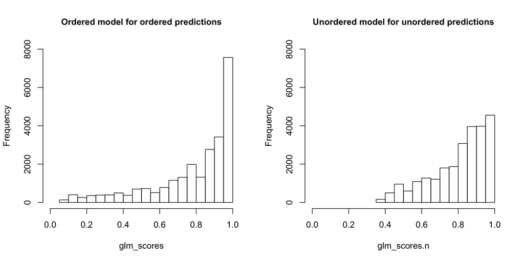

The histograms show the distribution of predicted scores for the ordered model on ordered data and the unordered model on unordered data. For the ordered model, 3481 predictions are less than 0.5 and thus rounded to 0. For the unordered model, only 1616 are less than 0.5 and rounded to 0. This discrepancy may be due to the higher overall coverage in the unordered dataset compared with the ordered dataset.

#### Test accuracy of models in predicting coverage on the other dataset (ordered model for unordered data and unordered model for ordered data)

##### Ordered model for unordered data

```r
set.seed(2)
ord4noord <- predict(cv.ord,newx = x_noord, s = cv.ord$lambda.1se, type="response")
rounded_scores <- round(ord4noord, digits = 0)
new <- cbind(cs_noord, rounded_scores)
length(which(new$covered==new$"1"))/nrow(new) # 78.424% accurate
```

```
## [1] 0.78424
```

##### Unordered model on ordered data

```r
set.seed(2)
# use non-ordered model on ordered data
noord4ord <- predict(cv.noord,newx = x, s = cv.noord$lambda.1se, type="response")
rounded_scores <- round(noord4ord, digits = 0)
new <- cbind(cs_ord, rounded_scores)
length(which(new$covered==new$"1"))/nrow(new) # 81.042% accurate
```

```
## [1] 0.81042
```

The results show that the model for the ordered data is 78.4% accurate in predicting coverage in the non-ordered data, and the model for non-ordered data is 81% accurate for predicting coverage in the ordered data.

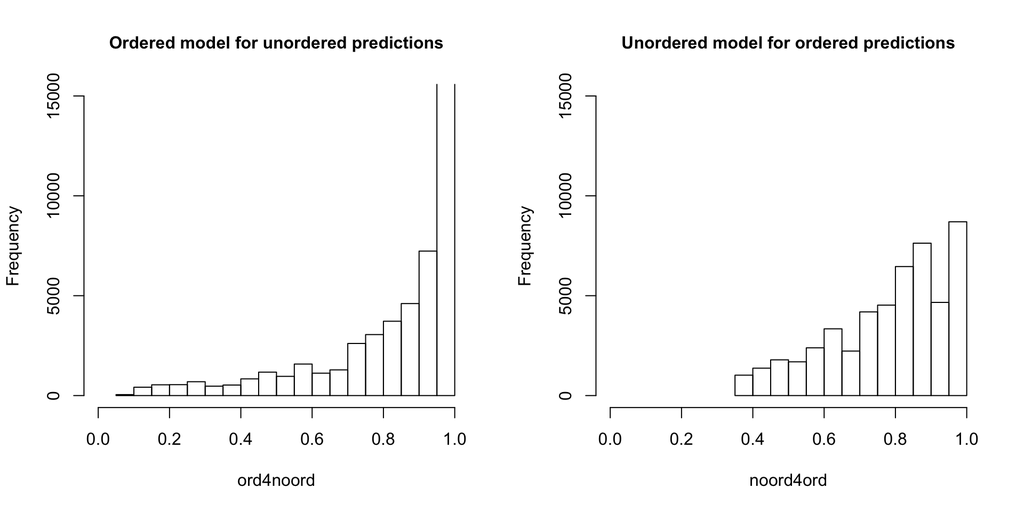

For the ordered model predicting unordered data, there are 5251 entries below 0.5 and thus rounded to 0, whereas for the unordered model predicting ordered data, there are only 4141 entries below 0.5 and rounded to 0. This discrepancy is likely to be due to the differences in true coverage between the ordered and unordered data.

#### Table showing the accuracy of cross validated model using the rounding approach

|  | Ordered test | Non-ordered test |
| --- | --- | --- |
| Ordered model | 84.07% | 78.4% |
| Non-ordered model | 81% | 79.9% |

(Interesting that the non-ordered model is better at predicting coverage in the ordered dataset than the non-ordered dataset - perhaps the ordered dataset is easier to predict. This claim will be checked later in the random forest section).

**Key point from this section: Coverage is predictable!!**

## Baseline model

The number of snps is fixed ($nsnps=100$) and the threshold is fixed ($thr=0.6$). The baseline model we wish to improve upon in this section is
$$log(\frac{p}{1-p})\sim log(\frac{size}{1-size})$$
Where $y=coverage$ and $p=prob(y=1)$. Note that we do not know p, in which case this analysis would be a lot easier.

#### Claim 1: This baseline model is a good predictor of coverage in non-ordered sets.

##### Method: Fit this model using training set and predict accuracy using test set for unordered data.

The training set had 1600 entries, the test set has 200 entries.

```r
set.seed(2)

# fix threshold and nsnps for ordered and non-ordered
cs_ <- cs_ord[cs_ord$thr=="0.6" & cs_ord$nsnps=="100",] # 1800 entries
cs_$size[cs_$size > 0.99999] <- 0.99999
# add column for logitsize predictor
logitsize <- log(cs_$size/(1-cs_$size))
cs_ <- cbind(cs_,logitsize)

cs_noord <- cs_noord[cs_noord$thr=="0.6" & cs_noord$nsnps=="100",] # 1800 entries
cs_noord$size[cs_noord$size > 0.99999] <- 0.99999
logitsize <- log(cs_noord$size/(1-cs_noord$size))
cs_noord <- cbind(cs_noord,logitsize)

# make test and training for non-ordered
test.n <- sample(nrow(cs_noord), 200) # randomly select rows to form the test set
test.n_set <- cs_noord[test.n, ] # mean covered is 0.82
training.n_set <- cs_noord[-test.n,] # mean covered is 0.80
xtraining.n        <- as.matrix(data.frame(training.n_set[,c(1:3,5:9)]))
xtest.n        <- as.matrix(data.frame(test.n_set[,c(1:3,5:9)]))

claim1_noord <- glm(covered ~ logitsize, data=training.n_set, family='binomial')
summary(claim1_noord)
```

```
##
## Call:
## glm(formula = covered ~ logitsize, family = "binomial", data = training.n_set)
##
## Deviance Residuals:
##      Min        1Q    Median        3Q       Max
## -2.69533   0.00496   0.13036   0.92362   0.97006
##
## Coefficients:
##             Estimate Std. Error z value Pr(>|z|)
## (Intercept)   0.1152     0.1051   1.096    0.273
## logitsize     0.9720     0.1224   7.940 2.03e-15 ***
## ---
## Signif. codes:  0 '***' 0.001 '**' 0.01 '*' 0.05 '.' 0.1 ' ' 1
##
## (Dispersion parameter for binomial family taken to be 1)
##
##     Null deviance: 1628.6  on 1599  degrees of freedom
## Residual deviance: 1275.6  on 1598  degrees of freedom
## AIC: 1279.6
##
## Number of Fisher Scoring iterations: 8
```

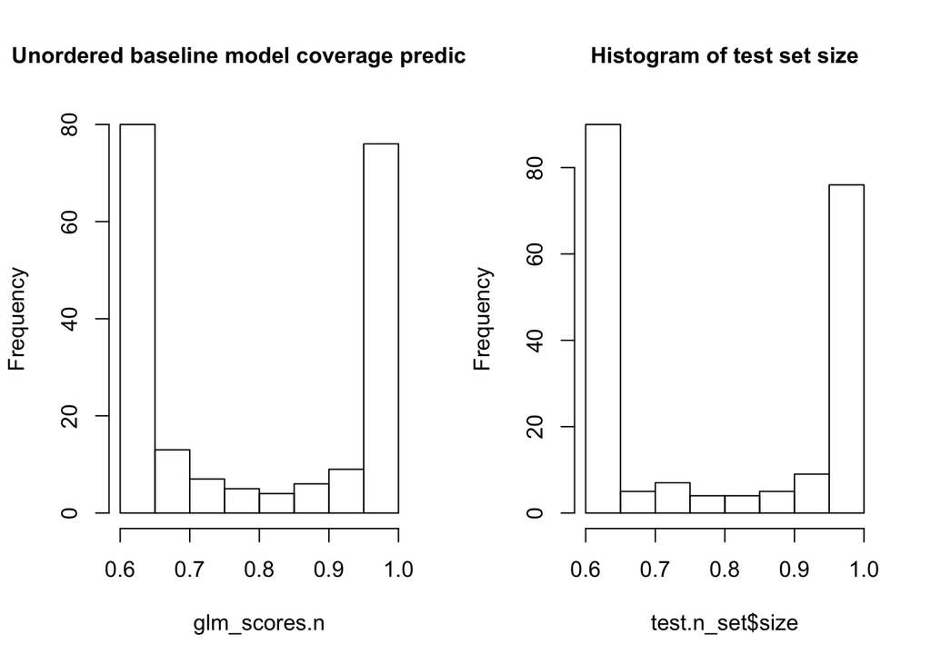

```r
# test out the accuracy of this model on the test unordered data
glm_scores.n <- predict(claim1_noord, as.data.frame(xtest.n), type="response")

par(mfrow=c(1,2))
hist(glm_scores.n,main="Unordered baseline model coverage prediction", cex.main=1)
hist(test.n_set$size,main="Histogram of test set size", cex.main=1)
```

The histograms show that the distribution of predicted scores is very close to the distribution of size values.

To test the accuracy of the baseline model for unordered data, the dataset was binned based on size and the true mean coverage of each bin was calculated. Binomial error bars were added.

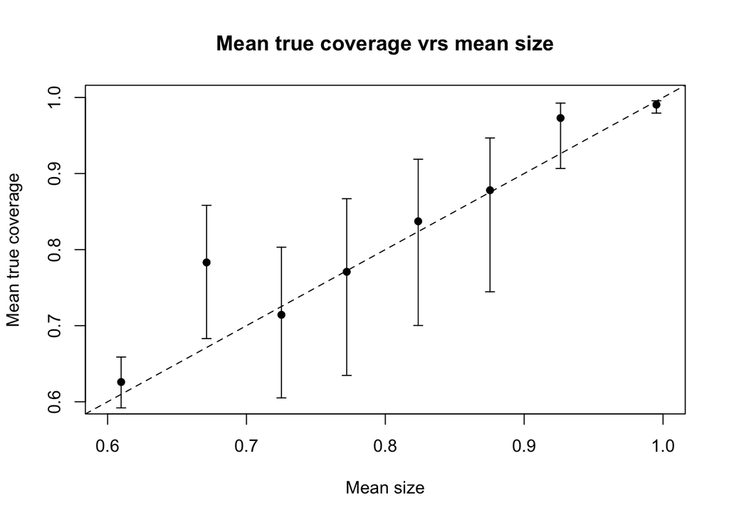

Next, the predicted coverage scores were binned similarly to the size values in the previous plot. The mean true coverage was plotted against the mean predicted coverage in each bin.

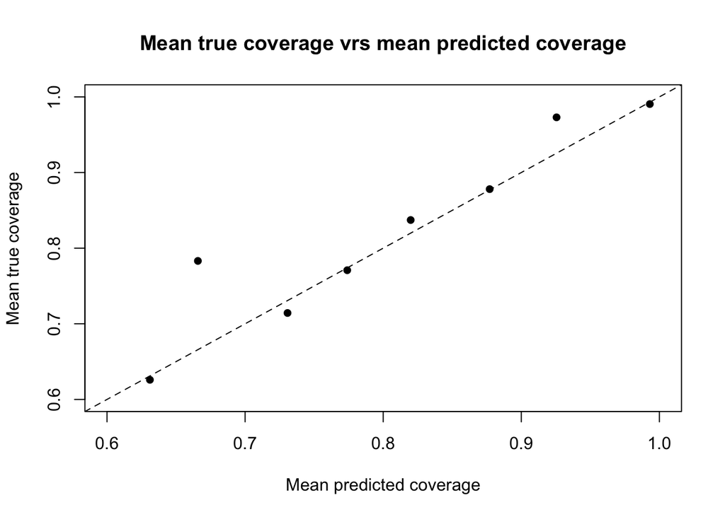

This suggests that the baseline model is fairly good at predicting coverage for the unordered data.

#### Fit the baseline model, coverage~logitsize, to the ordered data

To test how effective the baseline model is for ordered data, the model was fitted using ordered training set to predict ordered test set.

```r
set.seed(2)
test <- sample(nrow(cs_), 200) # randomly select rows to form the test set
test_set <- cs_[test, ]
training_set <- cs_[-test,]
xtraining        <- as.matrix(data.frame(training_set[,c(1:3,5:9)]))
xtest        <- as.matrix(data.frame(test_set[,c(1:3,5:9)]))

claim1_ord <- glm(covered ~ logitsize, data=training_set, family='binomial')
summary(claim1_ord) # Nb, saying that we are getting perfect seperation?
```

```
##
## Call:
## glm(formula = covered ~ logitsize, family = "binomial", data = training_set)
##
## Deviance Residuals:
##      Min        1Q    Median        3Q       Max
## -2.76392   0.00469   0.11719   0.98466   0.99572
##
## Coefficients:
##             Estimate Std. Error z value Pr(>|z|)
## (Intercept)  0.04296    0.09762   0.440     0.66
## logitsize    0.98817    0.13446   7.349    2e-13 ***
## ---
## Signif. codes:  0 '***' 0.001 '**' 0.01 '*' 0.05 '.' 0.1 ' ' 1
##
## (Dispersion parameter for binomial family taken to be 1)
##
##     Null deviance: 1788.4  on 1599  degrees of freedom
## Residual deviance: 1427.9  on 1598  degrees of freedom
## AIC: 1431.9
##
## Number of Fisher Scoring iterations: 8
```

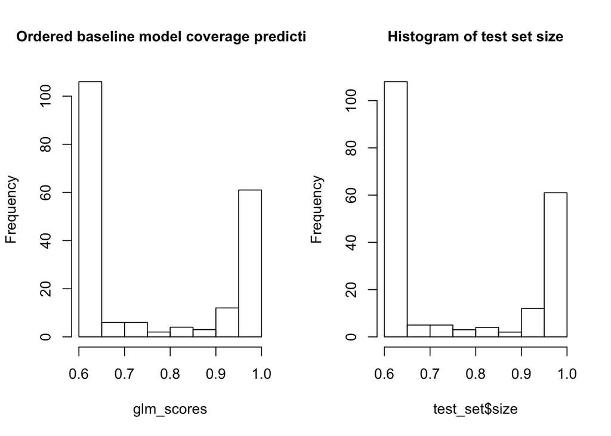

```r
# test out the accuracy of this model on the test ordered data
glm_scores <- predict(claim1_ord, as.data.frame(xtest), type="response")

par(mfrow=c(1,2))
hist(glm_scores,main="Ordered baseline model coverage prediction", cex.main=1) # notice none less than 0.6, so don't use rounding method
hist(test_set$size,main="Histogram of test set size", cex.main=1)
```

Notice that the AIC is higher for this baseline model using the odered data rather than the unordered data.

#### Claim 2: Improve accuracy of baseline model for ordered sets by including entropy as a predictor

##### Method: Run a glm on the ordered training set with logitsize and entropy as a predictor. Check the accuracy of predicting coverage in the ordered test set.

```r
claim2_ord <- glm(covered ~ logitsize+entropy, data=training_set, family='binomial')
summary(claim2_ord)
```

```
##
## Call:
## glm(formula = covered ~ logitsize + entropy, family = "binomial",
##     data = training_set)
##
## Deviance Residuals:
##      Min        1Q    Median        3Q       Max
## -2.75370   0.00369   0.11924   0.98616   1.00090
##
## Coefficients:
##             Estimate Std. Error z value Pr(>|z|)
## (Intercept)  -0.1099     0.8891  -0.124  0.90162
## logitsize     0.9454     0.2808   3.367  0.00076 ***
## entropy       0.0334     0.1931   0.173  0.86265
## ---
## Signif. codes:  0 '***' 0.001 '**' 0.01 '*' 0.05 '.' 0.1 ' ' 1
##
## (Dispersion parameter for binomial family taken to be 1)
##
##     Null deviance: 1788.4  on 1599  degrees of freedom
## Residual deviance: 1427.9  on 1597  degrees of freedom
## AIC: 1433.9
##
## Number of Fisher Scoring iterations: 8
```

```r
# Nb, saying that we are getting perfect seperation?

glm_scores1 <- predict(claim2_ord, as.data.frame(xtest), type="response")
```

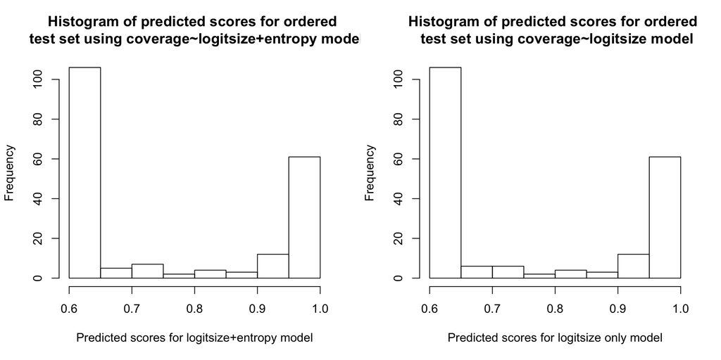

The histograms of predicted scores for the baseline model and the baseline model with entropy term are very similar. The entropy term is not significant in the model summary, and the AIC is higher for the model with the entropy term (1433.9 vrs 1431.9).

#### Comparison of coverage~logitsize (baseline model) and coverage~logitsize+entropy for ordered data.

We hope that the addition of the entropy predictor improves the baseline model for the ordered data. Unfortunately it seems that including entropy as a predictor does not change the predicted coverage scores much at all.

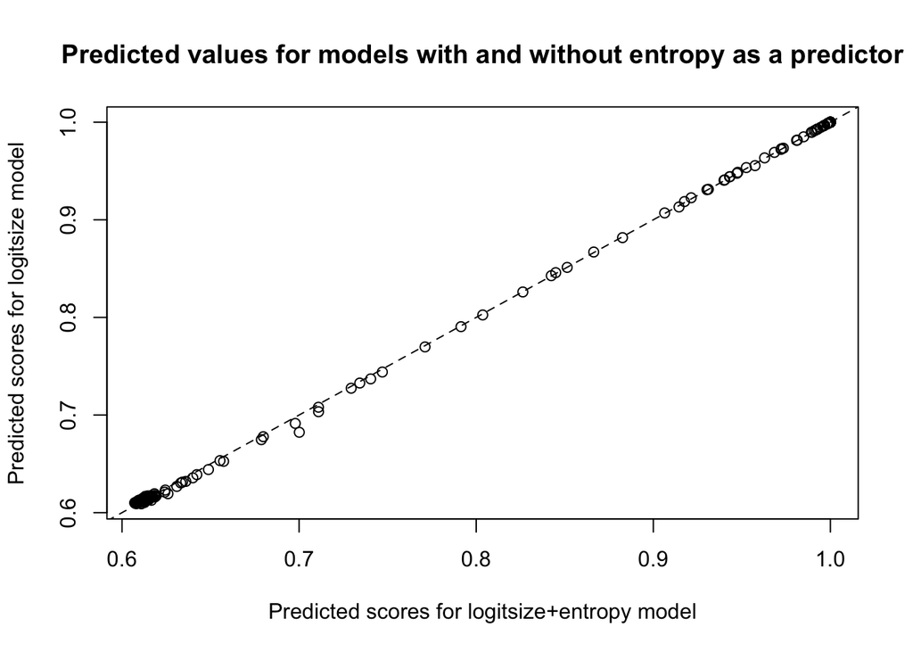

```r
plot(glm_scores1, glm_scores, xlab="Predicted scores for logitsize+entropy model", ylab="Predicted scores for logitsize model", main="Predicted values for models with and without entropy as a predictor")
abline(a=0,b=1,lty=2)
```

#### Claim 3: Adding OR to this model will not improve accuracy of covered~logitsize+entropy model.

##### Method: Run a glm on the ordered training set with logitsize, entropy and OR as predictors.

```r
set.seed(2)
claim3_ord <- glm(covered ~ logitsize+entropy+OR, data=training_set, family='binomial') # perfect seperation??
summary(claim3_ord) # OR term significant
```

```
##
## Call:
## glm(formula = covered ~ logitsize + entropy + OR, family = "binomial",
##     data = training_set)
##
## Deviance Residuals:
##      Min        1Q    Median        3Q       Max
## -2.61681   0.00594   0.08573   0.77722   1.79926
##
## Coefficients:
##             Estimate Std. Error z value Pr(>|z|)
## (Intercept) -27.7881     2.2565 -12.315  < 2e-16 ***
## logitsize     1.0198     0.2495   4.088 4.35e-05 ***
## entropy      -0.4072     0.1124  -3.622 0.000293 ***
## OR           28.0990     2.1365  13.152  < 2e-16 ***
## ---
## Signif. codes:  0 '***' 0.001 '**' 0.01 '*' 0.05 '.' 0.1 ' ' 1
##
## (Dispersion parameter for binomial family taken to be 1)
##
##     Null deviance: 1788.4  on 1599  degrees of freedom
## Residual deviance: 1201.0  on 1596  degrees of freedom
## AIC: 1209
##
## Number of Fisher Scoring iterations: 8
```

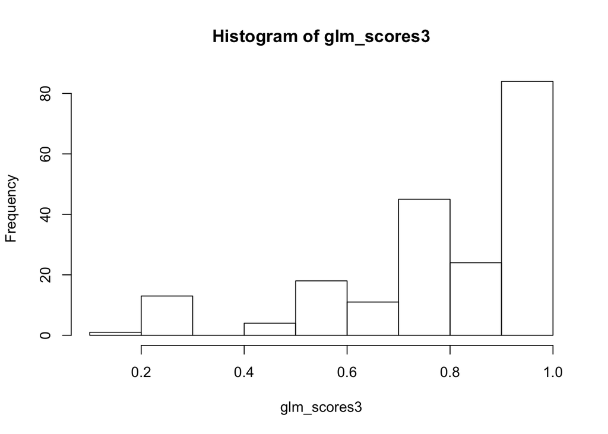

```r
glm_scores3 <- predict(claim3_ord, as.data.frame(xtest), type="response")
hist(glm_scores3)
```

```r
rounded_scores <- round(glm_scores3, digits = 0)
new <- cbind(test_set, rounded_scores)
length(which(new$covered==new$rounded_scores))/nrow(new) # 85% accurate
```

```
## [1] 0.85
```

This provides evidence against claim 3. It seems that by adding OR as a predictor, the AIC is reduced (1209 vrs 1433.9).

#### Claim 4: Entropy has a non-linear effect on coverage

##### Method: Run a glm on the ordered training set with logitsize and entropy as predictors. Use lrm and rcs to allow entropy to have a non-linear effect on coverage.

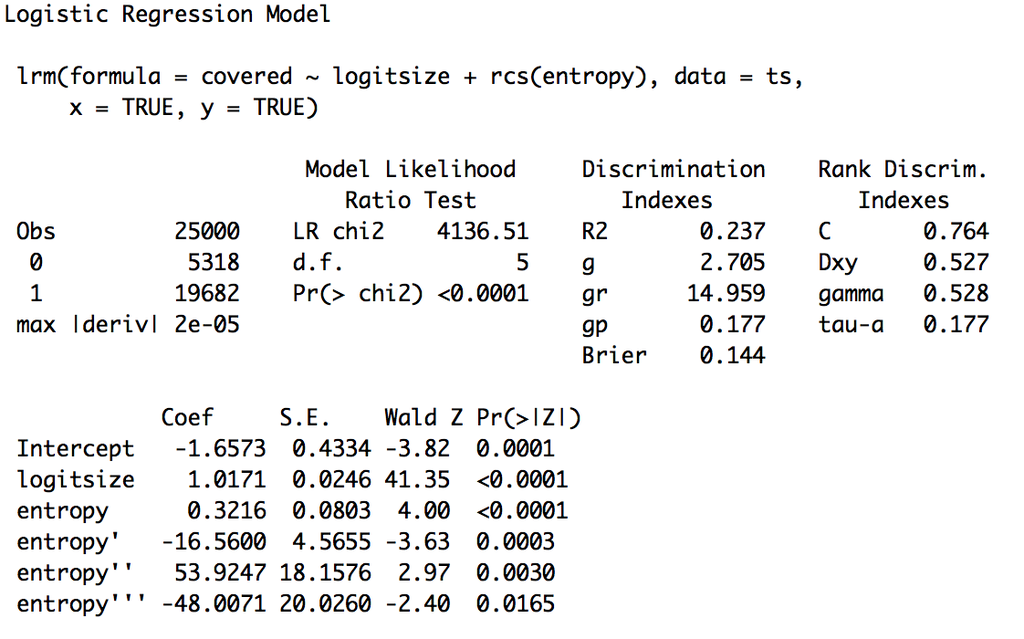

This model seems a good fit as all the terms have low p-values. Is there a way to find the AIC of this model?

The `calibrate` function is used to plot predicted values against observed values. Here “a nonparametric calibration curve is estimated over a sequence of predicted values” to allow us to see if the future predicted probabilities agree with the observed probabilities. In our case, it seems like they do.

```
plot(calibrate(y, B=500), main="Spline Model")
```

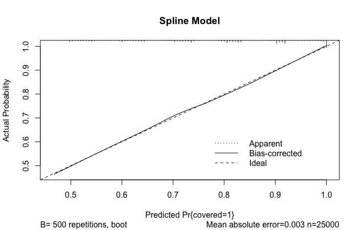

When using this model on the ordered test set, the accuracy is 78.2%. However, it would be good to find the AIC for this model to allow for comparisons with the other models.

##### Summary for models fitted to ordered data with thr=0.6, snps=100

|  | AIC |
| --- | --- |
| Covered~logitsize | 1431.9 |
| Covered~logitsize+entropy | 1433.9 |
| Covered~logitsize+entropy+OR | 1209 |
| Covered~logitsize+rcs(entropy) | unknown |

### Fit models for different fixed thr and nsnps values

The same models are fit for fixed:

1. thr=0.8 and nsnps=500
2. thr=0.9 and nsnps=1000

#### Summary of AIC for models fit

[output not shown]

It seems that the covered~logitsize+entropy+OR model is best (/lowest AIC) for the ordered data for all combinations of thr/nsnps studied.

### Random forest

Random forest algorithms were run on the ordered and unordered training datasets (both with 25000 entries) to see how well we can be expected to actually predict coverage.

#### Ordered

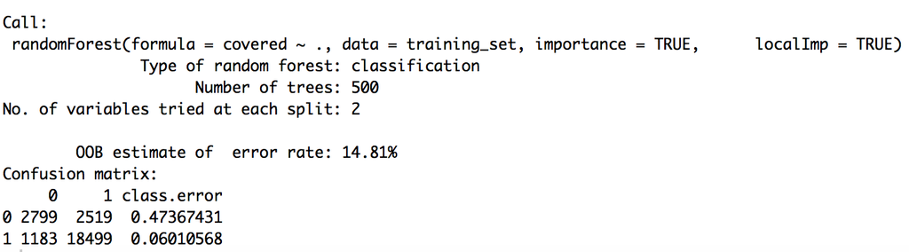

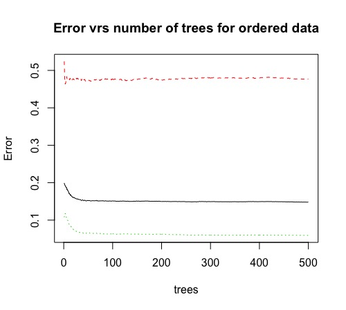

- The number of variables considered at each split is 2, I tried increasing this but it did not improve error rate.
- The following plot allows visualisation of the importance of each predictor. The higher the mean decrease accuracy and mean decrease gini scores, the more predictive.

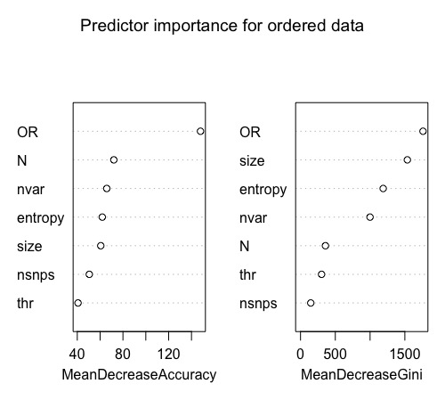

##### Prediction

- The ordered random forest obtained from the ordered training set was used to predict the ordered test set.
- Accuracy was 84.7%

#### Unordered

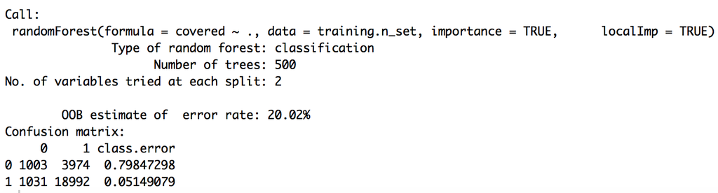

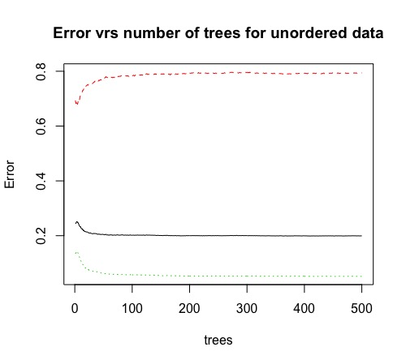

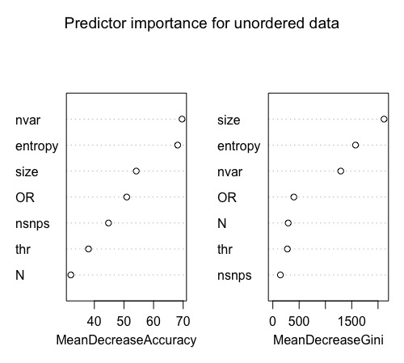

##### Prediction

- The unordered random forest obtained from the unordered training set was used to predict the unordered test set.
- Accuracy was 79.8% (lower than for the ordered).

#### Summary of random forest stuff

- The error rate is higher for unordered data, suggesting that coverage is easier to predict in ordered data.
- The class error for non-covered is 80% in unordered datasets, but only 47% in ordered datasets.
- This is promising as it suggests that we are able to predict coverage much better for ordered data than unordered data.
- Sure enough, prediction better for ordered data.

### Summary for supervisor meeting 4

#### 1. Correlations

- Coverage is highly correlated to OR in ordered (0.447) and less so in unordered (0.217).
- Coverage is correlated to entropy (0.2).
- Coverage is correlated to size in ordered (0.377) and unordered (0.401).
- Coverage is correlated to thr in ordered (0.22) and unordered (0.21).

#### 2. Accuracy of prediction

- Accuracy for all models tested hovers around 80%, showing that coverage is predictable but perhaps won’t be more accurate than 80%.
- Both the cross validated models (one fitted using ordered data and one fitted using unordered data) performed better on the ordered test set than the unordered test set, indicating that coverage is easier to predict in the ordered data.
- Moreover, prediction in the random forest section was better when using ordered data over unordered.

**- Coverage for the ordered data is easier to predict than coverage for the unordered data.**

#### 3. Baseline model/ adding entropy/ adding OR

- The baseline model seems slightly better when fit to unordered data (lower AIC), but should test this theory in another way?
- Adding entropy term to the baseline model for ordered data actually increases AIC.
- Adding OR to the baseline+entropy model does decrease AIC (better model).

### Next direction/ questions

- Is there another way to test how accurate the baseline model is for unordered and ordered data, apart from looking at AIC?
- Try a different entropy term that better captures OR of the system. At the moment we are using
  $$entropy=-mean(log(pp))$$
- I’ve had a play around with the ordered data, and without OR as a predictor, the best accuracy I can get is approx. 78%, but with OR it is approx. 85%.
- When removing information about OR, several other predictors are now dropped for the cv glmnet model, namely thr, nvar, entropy and nsnps.